# Anti-freeze-protein-classification EDA & PCA

# 4 Zero Variance & Near-Zero Variance Testing

The Zero Variance and Near-Zero Variance tests belong within the [R/caret](https://topepo.github.io/caret/) package written by [Max Kuhn](http://appliedpredictivemodeling.com/).

Sparse matrices are quite common and can be problematic for certain calculations. Biological data is no different. In order to easily reduce the number of features within biological data one can test if features have no variance or very little variance. When using the `caret::nearZeroVar(df, saveMetrics = TRUE)` the output is an N by 4 matrix. Both column 3 and 4 return a boolean values where column 3 is labeled **zeroVar** column 4 is labeled **nzv**. The frequency ratio (`freqRatio`) and percent unique (`percentUnique`) provide numeric values that can allow more or less stringent parsing of observations to use or not.

## 4.1 Check for Near-Zero Variance using Caret

```r
df <- all_proteins[c(3:1742)]
nzv <- nearZeroVar(df, saveMetrics = TRUE)
head(nzv)
```

```
##    freqRatio percentUnique zeroVar   nzv
## X3     16.25      82.87462   FALSE FALSE
## X4     88.50      53.21101   FALSE FALSE
## X5     31.00      69.11315   FALSE FALSE
## X6     34.50      71.96738   FALSE FALSE
## X7     41.00      67.17635   FALSE FALSE
## X8     19.50      78.49134   FALSE FALSE
```

## 4.2 Table of Zero Variance Variables

```r
table(nzv$zeroVar)
```

```
##
## FALSE
##  1740
```

Note 6: No Zero-Variance features. FALSE indicates NO features have variance equal to zero.

## 4.3 Table of Near-Zero Variance Variables

```r
table(nzv$nzv)
```

```
##
## FALSE  TRUE
##  1223   517
```

Note 7: The table above “Near-Zero Variance” shows that 517 out of the 1740 have Near-Zero Variance.

## 4.4 Summary of Near-Zero Variance to find 1st quartile cut-off

```r
summary(nzv$percentUnique)
```

```
##    Min. 1st Qu.  Median    Mean 3rd Qu.    Max.
##  0.9174  8.9450 14.3731 18.6569 19.9796 84.0979
```

Note 8: Using the first quartile value of 8.9450 will reduce the number of features by approximately 1/4.

```r
# How many features have Near-Zero Variance
print(length(nzv[nzv$zeroVar == TRUE, ]))
```

```
## [1] 4
```

```r
print(paste('Column count before cutoff:', ncol(df)))
```

```
## [1] "Column count before cutoff: 1740"
```

## 4.5 Remove zero and bottom quartile of near-zero variance

```r
# remove zero & near-zero variance from df_nzv
df_nzv <- df[c(rownames(nzv[nzv$percentUnique > 8.9450, ])) ]

print(paste('Column count after cutoff:', ncol(df_nzv)))
```

```
## [1] "Column count after cutoff: 1305"
```

# 5 Principal Component Analysis

```r
start_time <- Sys.time() # Start timer

pmatrix <- scale(df_nzv)
pca_model <- prcomp(pmatrix)

end_time <- Sys.time() # End timer
end_time - start_time # Display elapsed time
```

```
## Time difference of 4.069978 secs
```

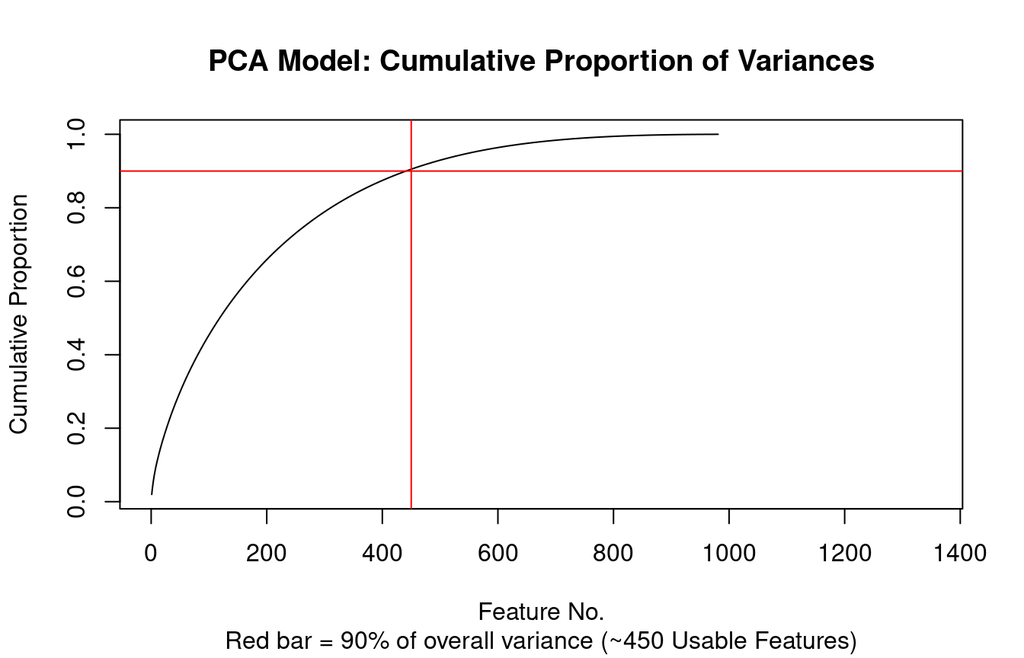

```r
plot(cumsum(pca_model$sdev^2 / sum(pca_model$sdev^2)),
     type = "l",
     main = "PCA Model: Cumulative Proportion of Variances",
     sub = "Red bar = 90% of overall variance (~450 Usable Features)",
     xlab = "Feature No.",
     ylab = "Cumulative Proportion",
     xlim = c(0, 1350))
abline(v = 450, col = "red")
abline(h = 0.9, col = "red")
```

See: https://github.com/amunategui/pca-dimension-reduction/blob/master/pca.R